# Project506-Caconical Correlation Analysis

Menghan Lin, Chunhui Lin, Xinyu Wu

November 26, 2018

# Introduction

**Canonical correlation** is a method to assess correlations between two sets of variables. Canonical correlation is appropriate in the same situations where multiple regression would be, but where are there are many intercorrelated outcome variables.

The following example is an replication of paper Examination of the relationships between environmental exposures to volatile organic compounds(VOCs) and biochemical liver tests: Application of canonical correlation analysis.

Instead of repeating the examination, we further investigate the correlation in the subgroup controlling on people who have more than 12 times drinks per year.

The typical purposes of CCA are: 1.Data reduction: explain covariation between two sets of variables using small number of linear combinations. 2. Data interpretation: find features (canonical variates) that are important for explaining covariation between sets of variables.

**Note** Canonical correlation terminology makes an important distinction between the words variables and variates. The term variables is reserved for referring to the original variables being analyzed. The term variates is used to refer to variables that are constructed as weighted averages of the original variables. Thus, a set of Y variates is construxted from the original Yvariables.

# Derivation

If we have two vectors $X = (X_1 ,X_2,.X_n )^T$ and $Y = (Y_1,Y_2,.Y_m )^T$ of random variables, and there are correlations among the variables, then canonical-correlation analysis seeks the vectors $a(a\in R_n)$ and $b(b\in R_m)$ such that the linear combinations $a^TX$ and $b^TY$ maximize the correlation $\rho= corr(a^TX,b^TY)$. In short, it can be expressed as:

$$(a,b)=arg\max_{a,b}corr(a^TX,b^TY)$$

Let $\Sigma_{XX}=cov(X,X)$ and $\Sigma_{YY}=cov(Y,Y)$. The parameter to maximize is$\rho={{a^T\Sigma_{XY}b}\over{\sqrt{a^T \Sigma_{XX}a}\sqrt{b^T \Sigma_{YY}b}}}$.

To define a change of basis, we set:

$$c=\Sigma_{XX}^{-\frac{1}{2}}a$$

$$d=\Sigma_{YY}^{-\frac{1}{2}}b$$

thus, we have:

$$\rho={{c^T \Sigma_{XX}^{-\frac{1}{2}}\Sigma_{XY}\Sigma_{YY}^{-\frac{1}{2}}d}\over {\sqrt{c^Tc}\sqrt{d^Td}}}$$

By the Cauchy-Schwarz inequality, we have:

$$(c^T \Sigma_{XX} ^{-\frac{1}{2}} \Sigma_{XY} \Sigma_{YY} ^{-\frac{1}{2}}) d \leq (c^T \Sigma_{XX} ^{-\frac{1}{2}} \Sigma_{XY} \Sigma_{YY} ^{-1} \Sigma_{YX} \Sigma_{XX} ^{-\frac{1}{2}} c)^{-\frac{1}{2}} (d^T d)^{-\frac{1}{2}}$$

After canceling the term $(d^T d)^{-\frac{1}{2}}$, we have:

$$\rho \leq {{(c^T\Sigma_{XX}^{-\frac{1}{2}}\Sigma_{XY}\Sigma_{YY}^{-1}\Sigma_{XX}^{-\frac{1}{2}}c)^{-\frac{1}{2}}}\over{\sqrt{c^Tc}}}$$

There is equality if the vectors d and $(c^T \Sigma_{XX} ^{-\frac{1}{2}} \Sigma_{XY} \Sigma_{YY} ^{-\frac{1}{2}})^T$ are colinear. In addition, the maximum of correlation is attained if c is the eigenvector with the maximum eigenvalue for the matrix $\Sigma_{XX} ^{-\frac{1}{2}} \Sigma_{XY} \Sigma_{YY} ^{-1} \Sigma_{YX} \Sigma_{XX} ^{-\frac{1}{2}}$.

The subsequent pairs are found by using eigenvalues of decreasing magnitudes. Orthogonality is guaranteed by the symmetry of the correlation matrices.

# Data description

The VOC Project of personal exposures to air toxics was conducted among a subsample of *(NHANES 1999-2000)[https://wwwn.cdc.gov/nchs/nhanes/Search/DataPage.aspx?Component=Questionnaire&CycleBeginYear=1999]* participants between the ages of 20 and 59 years. This tutorial include 565 observations with 10VOCs: benzene, chloroform, ethylbenzene, tetrachloroethene, toluene, trichloroethene, o-xylene, m-,p-xylene, 1,4-dichloro- benzene, andmethyl tert-butyl ether(MTBE). Besides, liver condition serves as the outcome variables, which was measured by albumin, totalbilirubin(TB), alanineaminotransfer- ase (ALT), aspartateaminotransferase(AST), lactatedehydrogenase(LDH), alkaline phosphatase (ALP) and g-glutamyltransferase(GGT). Controlling on people who drink more than 12 times per year, the subgroup descriptive statstics are also listed below.

Descriptive statistics of personal exposure to 10 VOCs and biochemical liver tests

**Figure 1.** Personal exposures to 10 VOCs.

|  | n | min | mean | median | 90th percentile | 95th percentile |
| --- | --- | --- | --- | --- | --- | --- |
| 1,4-Dichlorobenzene | 556 | 0.62 | 46.96 | 2.08 | 104.93 | 257.94 |
| Benzene | 557 | 1.25 | 5.36 | 2.88 | 11.16 | 17.22 |
| o-Xylene | 556 | 0.31 | 6.17 | 2.11 | 12.13 | 21.59 |
| m,p-Xylene | 556 | 0.34 | 17.76 | 5.97 | 33.99 | 61.17 |
| Ethylbenzene | 552 | 0.20 | 7.69 | 2.33 | 11.53 | 21.94 |
| MTBE | 555 | 0.60 | 6.13 | 0.60 | 13.69 | 23.47 |
| Toluene | 548 | 2.69 | 34.54 | 16.02 | 54.64 | 92.24 |
| Chloroform | 561 | 0.32 | 2.69 | 1.14 | 6.16 | 10.36 |
| Tetrachloroethene | 553 | 0.18 | 4.59 | 0.78 | 6.24 | 16.15 |
| Trichloroethene | 556 | 0.27 | 4.09 | 0.27 | 1.19 | 6.75 |

**Figure 2.** Biochemical liver tests.

|  | n | min | mean | median | 90th percentile | 95th percentile |
| --- | --- | --- | --- | --- | --- | --- |
| Albumin | 555 | 33.0 | 44.37 | 45.0 | 49.0 | 50.0 |
| ALT | 555 | 7.0 | 26.46 | 20.0 | 45.6 | 57.0 |
| ALP | 555 | 28.0 | 81.47 | 78.0 | 112.6 | 129.0 |
| AST | 555 | 9.0 | 23.99 | 21.0 | 34.0 | 40.3 |
| GGT | 555 | 5.0 | 30.13 | 20.0 | 51.0 | 74.0 |
| LDH | 555 | 63.0 | 147.38 | 144.0 | 182.0 | 195.3 |
| TB | 555 | 1.7 | 9.21 | 8.6 | 13.7 | 17.1 |

Descriptive statistics of personal exposure to 10 VOCs and biochemical liver tests(subgroup)

**Figure 3.** Personal exposures to 10 VOCs.(subgroup)

|  | n | min | mean | median | 90th percentile | 95th percentile |
| --- | --- | --- | --- | --- | --- | --- |
| 1,4-Dichlorobenzene | 356 | 0.62 | 45.29 | 1.83 | 62.80 | 223.88 |
| Benzene | 359 | 1.25 | 5.48 | 2.88 | 10.95 | 17.66 |
| o-Xylene | 358 | 0.31 | 6.91 | 2.23 | 12.48 | 24.55 |
| m,p-Xylene | 358 | 0.34 | 20.78 | 6.34 | 37.13 | 80.74 |
| Ethylbenzene | 356 | 0.20 | 9.57 | 2.46 | 12.96 | 27.76 |
| MTBE | 356 | 0.60 | 5.96 | 0.60 | 13.23 | 22.58 |
| Toluene | 351 | 2.69 | 38.15 | 16.13 | 54.61 | 92.12 |
| Chloroform | 361 | 0.32 | 2.44 | 1.11 | 5.10 | 8.77 |
| Tetrachloroethene | 356 | 0.18 | 4.98 | 0.82 | 5.38 | 14.76 |
| Trichloroethene | 360 | 0.27 | 2.93 | 0.27 | 1.17 | 7.53 |

**Figure 4.** Biochemical liver tests.(subgroup)

|  | n | min | mean | median | 90th percentile | 95th percentile |
| --- | --- | --- | --- | --- | --- | --- |
| Albumin | 357 | 33.0 | 44.79 | 45.0 | 49.0 | 50.00 |
| ALT | 357 | 8.0 | 28.67 | 22.0 | 51.4 | 65.00 |
| ALP | 357 | 28.0 | 79.68 | 76.0 | 109.0 | 122.40 |
| AST | 357 | 9.0 | 25.21 | 22.0 | 35.0 | 45.20 |
| GGT | 357 | 5.0 | 34.41 | 21.0 | 62.4 | 93.00 |
| LDH | 357 | 63.0 | 147.42 | 143.0 | 187.0 | 199.00 |
| TB | 357 | 3.4 | 9.55 | 8.6 | 15.4 | 17.44 |

**Note**: To avoid potential confounding, we excluded the patients who had liver conditions, heart disease, stroke, cancer or diabetes. Those tested serum positive to hepatitis C virus (HCV) were also excluded. One observation with extreme values in ALT(1163U/L) and AST(827U/L) is also excluded.

To satisfy the assumption of CCA, we also transformed the VOC and liver function test variables to Blom normal scores ($s = \Phi(\frac{r-3/8} {n +1/4})$) from their ranks to assure the multivariate normality is not violatied.

# Software

## **R**

This tutorial uses the following packages.

```r
library(yacca)
library(data.table)
library(dplyr)
```

**Canonical structures of the first pair of canonical variate and F-test (full group)**

```
#Display raw canonical coefficients
cca.fit$xcoef
cca.fit$ycoef
```

**Figure 5.** Canonical coefficients of personal exposures to VOCs.

|  | CV 1 | CV 2 | CV 3 | CV 4 | CV 5 | CV 6 | CV 7 |
| --- | --- | --- | --- | --- | --- | --- | --- |
| 1,4-Dichlorobenzene | 0.08 | 0.83 | 0.08 | 0.37 | 0.11 | 0.09 | -0.25 |
| Benzene | 0.81 | 0.08 | -0.59 | -0.30 | 0.45 | 0.55 | 0.18 |
| o-Xylene | 0.62 | 0.69 | 0.95 | 0.34 | -0.64 | -0.88 | -1.04 |
| m,p-Xylene | -0.24 | -0.63 | -0.56 | -0.20 | -0.13 | 1.46 | 0.30 |
| Ethylbenzene | -0.03 | -0.29 | 0.08 | 0.82 | 0.60 | -0.39 | 0.42 |
| MTBE | 0.32 | -0.02 | 0.05 | -0.66 | -0.11 | -0.54 | -0.64 |
| Toluene | -0.18 | -0.22 | 0.16 | -0.21 | 0.01 | -0.98 | 0.55 |
| Chloroform | -0.35 | -0.29 | -0.04 | 0.07 | 0.81 | -0.07 | -0.46 |
| Tetrachloroethene | -0.07 | 0.21 | 0.82 | -0.39 | 0.21 | 0.49 | 0.47 |
| Trichloroethene | -0.03 | 0.51 | -0.74 | -0.06 | 0.08 | -0.49 | 0.39 |

**Figure 6.** Canonical coefficients of biochemical liver tests.

|  | CV 1 | CV 2 | CV 3 | CV 4 | CV 5 | CV 6 | CV 7 |
| --- | --- | --- | --- | --- | --- | --- | --- |
| Albumin | 0.97 | -0.24 | 0.64 | 0.20 | -0.09 | 0.06 | -0.07 |
| ALT | 0.09 | -0.63 | -0.69 | 0.27 | 0.17 | -0.90 | 1.16 |
| ALP | 0.52 | 0.61 | -0.51 | 0.15 | -0.39 | -0.22 | -0.28 |
| AST | -0.14 | 0.02 | 0.44 | -1.19 | -0.71 | -0.03 | -0.88 |
| GGT | 0.04 | 0.11 | -0.22 | -0.32 | 0.60 | 1.18 | 0.05 |
| LDH | -0.09 | 0.65 | 0.56 | 0.13 | 0.65 | -0.27 | 0.37 |
| TB | -0.63 | 0.40 | -0.01 | 0.34 | -0.66 | 0.37 | 0.51 |

Next, we are going to compute the loadings of variables on the canonical dimensions(variates). Canonical loadings are known as the correlations between observed variables and canonical variables. These canonical variates are actually a type of latent variable.

```
cca.fit$corr
cca.fit$xstructcorr #Loadings
cca.fit$ystructcorr
F.test.cca(cca.fit)
```

```
##       CV 1       CV 2       CV 3       CV 4       CV 5       CV 6
## 0.31838580 0.23136020 0.19211314 0.11436996 0.10021086 0.06559313
##       CV 7
## 0.02455458
```

**Figure 7.** Loadings of variables (VOCs).

|  | CV 1 | CV 2 | CV 3 | CV 4 | CV 5 | CV 6 | CV 7 |
| --- | --- | --- | --- | --- | --- | --- | --- |
| 1,4-Dichlorobenzene | 0.09 | 0.73 | 0.11 | 0.35 | 0.26 | -0.03 | -0.19 |
| Benzene | 0.87 | -0.10 | -0.12 | -0.01 | 0.39 | 0.08 | 0.13 |
| o-Xylene | 0.70 | -0.12 | 0.38 | 0.38 | 0.10 | -0.19 | 0.01 |
| m,p-Xylene | 0.67 | -0.21 | 0.29 | 0.37 | 0.16 | -0.08 | 0.12 |
| Ethylbenzene | 0.58 | -0.22 | 0.26 | 0.49 | 0.26 | -0.21 | 0.24 |
| MTBE | 0.43 | 0.01 | 0.14 | -0.55 | 0.11 | -0.35 | -0.32 |
| Toluene | 0.45 | -0.18 | 0.29 | 0.16 | 0.25 | -0.51 | 0.33 |
| Chloroform | -0.21 | -0.11 | 0.08 | 0.00 | 0.84 | -0.09 | -0.38 |
| Tetrachloroethene | 0.07 | 0.27 | 0.63 | -0.39 | 0.37 | 0.13 | 0.39 |
| Trichloroethene | 0.02 | 0.48 | -0.29 | -0.13 | 0.22 | -0.31 | 0.38 |

**Figure 8.** Loadings of variables (biochemical liver tests).

|  | CV 1 | CV 2 | CV 3 | CV 4 | CV 5 | CV 6 | CV 7 |
| --- | --- | --- | --- | --- | --- | --- | --- |
| Albumin | 0.68 | -0.13 | 0.48 | 0.00 | -0.32 | 0.22 | 0.38 |
| ALT | 0.28 | -0.06 | -0.19 | -0.56 | -0.11 | -0.16 | 0.73 |
| ALP | 0.51 | 0.66 | -0.49 | -0.11 | -0.19 | -0.10 | 0.00 |
| AST | 0.13 | 0.14 | 0.14 | -0.87 | -0.29 | -0.09 | 0.32 |
| GGT | 0.33 | 0.16 | -0.23 | -0.55 | 0.16 | 0.54 | 0.45 |
| LDH | 0.06 | 0.64 | 0.38 | -0.33 | 0.32 | -0.26 | 0.40 |
| TB | -0.11 | 0.24 | 0.20 | 0.03 | -0.65 | 0.33 | 0.60 |

```
##
##  F Test for Canonical Correlations (Rao's F Approximation)
##
##           Corr         F    Num df Den df    Pr(>F)
## CV 1  0.318386  1.821520 70.000000 3202.2 4.284e-05 ***
## CV 2  0.231360  1.244772 54.000000 2804.0    0.1096
## CV 3  0.192113  0.912402 40.000000 2400.2    0.6283
## CV 4  0.114370  0.557007 28.000000 1988.1    0.9709
## CV 5  0.100211  0.461607 18.000000 1561.8    0.9733
## CV 6  0.065593  0.272125 10.000000 1106.0    0.9871
## CV 7  0.024555  0.083556  4.000000  554.0    0.9875
## ---
## Signif. codes:  0 '***' 0.001 '**' 0.01 '*' 0.05 '.' 0.1 ' ' 1
```

*A cutoff value of 0.35 are chosen to select important loadings.*

The first canonical correlation coefficient was 0.318. The first canonical correlation was statistically significant (F = 1.82, p < 0.05) indicating that two sets of variables were correlated. From the result, we found that personal exposure to Benzene, o-Xylene, m,p-Xylene, Ethylbenzene, MTBE and Toluene as a group might addect the serum levels of Albumin and ALP.

**Canonical structures of the first pair of canonical variate and F-test (subgroup)**

```
#Display raw canonical coefficients (subgroup)
cca.fit1$xcoef
cca.fit1$ycoef
```

**Figure 9.** Canonical coefficients of personal exposures to VOCs.

|  | CV 1 | CV 2 | CV 3 | CV 4 | CV 5 | CV 6 | CV 7 |
| --- | --- | --- | --- | --- | --- | --- | --- |
| 1,4-Dichlorobenzene | -0.09 | 0.79 | -0.35 | 0.44 | 0.19 | 0.05 | 0.30 |
| Benzene | 0.95 | -0.13 | -0.51 | -0.20 | 0.31 | -0.16 | 0.28 |
| o-Xylene | 0.39 | 1.14 | 0.80 | -0.70 | 0.03 | -0.53 | 0.17 |
| m,p-Xylene | -0.08 | -0.62 | -0.23 | 1.10 | -0.26 | 1.21 | -1.89 |
| Ethylbenzene | -0.20 | -0.19 | 0.13 | 0.24 | 0.77 | -0.79 | 1.00 |
| MTBE | 0.39 | 0.00 | -0.24 | -0.32 | -0.19 | -0.13 | -0.02 |
| Toluene | -0.28 | -0.13 | 0.47 | -0.26 | -0.97 | -0.32 | 0.60 |
| Chloroform | -0.38 | -0.22 | 0.12 | -0.26 | 0.51 | -0.63 | -0.29 |
| Tetrachloroethene | -0.16 | 0.47 | 0.22 | -0.69 | 0.28 | 0.48 | 0.06 |
| Trichloroethene | -0.12 | 0.18 | -0.61 | 0.16 | -0.71 | -0.61 | -0.55 |

**Figure 10.** Canonical coefficients of biochemical liver tests.

|  | CV 1 | CV 2 | CV 3 | CV 4 | CV 5 | CV 6 | CV 7 |
| --- | --- | --- | --- | --- | --- | --- | --- |
| Albumin | 0.85 | 0.23 | 0.81 | 0.05 | -0.01 | 0.13 | -0.05 |
| ALT | 0.00 | -0.71 | -0.06 | 0.39 | -1.51 | -0.43 | 0.71 |
| ALP | 0.30 | 0.32 | -0.39 | 0.67 | -0.19 | -0.10 | -0.63 |
| AST | -0.01 | -0.35 | 0.12 | -0.84 | 0.60 | 0.27 | -1.37 |
| GGT | 0.42 | 0.01 | -0.68 | -0.28 | 1.02 | 0.23 | 0.62 |
| LDH | -0.07 | 0.90 | -0.09 | -0.47 | -0.41 | 0.06 | 0.43 |
| TB | -0.69 | -0.01 | -0.17 | 0.41 | -0.11 | 0.91 | 0.11 |

```
cca.fit1$corr
cca.fit1$xstructcorr
cca.fit$xstructcorr
cca.fit1$ystructcorr
cca.fit$ystructcorr
F.test.cca(cca.fit1)
```

```
##       CV 1       CV 2       CV 3       CV 4       CV 5       CV 6
## 0.34584676 0.27173286 0.20181075 0.14155267 0.08342351 0.07952745
##       CV 7
## 0.03187424
```

**Figure 11.** Loadings of variables (VOCs).

|  | CV 1 | CV 2 | CV 3 | CV 4 | CV 5 | CV 6 | CV 7 |
| --- | --- | --- | --- | --- | --- | --- | --- |
| 1,4-Dichlorobenzene | -0.08 | 0.74 | -0.20 | 0.33 | 0.14 | -0.15 | 0.27 |
| Benzene | 0.82 | 0.11 | 0.09 | -0.06 | 0.09 | -0.32 | 0.05 |
| o-Xylene | 0.47 | 0.38 | 0.65 | 0.19 | -0.01 | -0.29 | -0.27 |
| m,p-Xylene | 0.46 | 0.28 | 0.60 | 0.27 | -0.01 | -0.25 | -0.33 |
| Ethylbenzene | 0.32 | 0.21 | 0.51 | 0.30 | 0.12 | -0.44 | -0.02 |
| MTBE | 0.41 | 0.10 | -0.16 | -0.42 | -0.10 | -0.21 | -0.10 |
| Toluene | 0.23 | 0.21 | 0.58 | -0.01 | -0.42 | -0.39 | 0.22 |
| Chloroform | -0.27 | -0.02 | 0.05 | -0.32 | 0.42 | -0.59 | -0.26 |
| Tetrachloroethene | -0.08 | 0.51 | 0.08 | -0.65 | 0.07 | 0.11 | -0.13 |
| Trichloroethene | -0.15 | 0.31 | -0.43 | -0.10 | -0.38 | -0.44 | -0.39 |

**Figure 12.** Loadings of variables (biochemical liver tests).

|  | CV 1 | CV 2 | CV 3 | CV 4 | CV 5 | CV 6 | CV 7 |
| --- | --- | --- | --- | --- | --- | --- | --- |
| Albumin | 0.69 | 0.00 | 0.44 | 0.05 | -0.14 | 0.56 | 0.06 |
| ALT | 0.43 | -0.44 | -0.36 | -0.27 | -0.58 | 0.30 | 0.05 |
| ALP | 0.43 | 0.26 | -0.60 | 0.36 | -0.24 | 0.08 | -0.43 |
| AST | 0.29 | -0.28 | -0.28 | -0.57 | -0.31 | 0.43 | -0.40 |
| GGT | 0.58 | -0.22 | -0.59 | -0.20 | 0.07 | 0.40 | 0.24 |
| LDH | 0.11 | 0.57 | -0.28 | -0.57 | -0.46 | 0.23 | 0.02 |
| TB | -0.09 | -0.08 | -0.05 | 0.17 | -0.18 | 0.96 | 0.03 |

```
##
##  F Test for Canonical Correlations (Rao's F Approximation)
##
##           Corr         F    Num df  Den df Pr(>F)
## CV 1  0.345847  1.428028 70.000000 2030.16 0.0124 *
## CV 2  0.271733  1.002686 54.000000 1779.05 0.4701
## CV 3  0.201811  0.671618 40.000000 1524.05 0.9428
## CV 4  0.141553  0.434890 28.000000 1263.37 0.9957
## CV 5  0.083424  0.280575 18.000000  993.26 0.9987
## CV 6  0.079527  0.259591 10.000000  704.00 0.9892
## CV 7  0.031874  0.089750  4.000000  353.00 0.9856
## ---
## Signif. codes:  0 '***' 0.001 '**' 0.01 '*' 0.05 '.' 0.1 ' ' 1
```

The first canonical correlation coefficient was 0.34. The pooled sum of squares of all canonical correlation coefficients was 0.269, which was contributed by 44.5% by the first canonical correlation. Compared to the full group, the subgroup analysis narrowed down the relationship bwterrn the VOC exposure and liver function to fewer numbers of VOCs but more liver function tests. The first canonical correlation indicated that Benzene, o-Xylene, m,p-Xylene and MTBE as a group might affect the serum levels of albumin, ALP, ALT and GGT.

## **Stata**

We need to load the data into STATA using import delimited.

```
. import delimited data.csv
(18 vars, 565 obs)
```

To view the first three rows of data, we use **list** command.

```
. list in 1/3

     +-----------------------------------------------------------------------+
  1. | v1  |        v2  |   benzene  |   oxylene  |  mpxylene  |  ethylbe~e  |
     |  1  |  1.037667  | -1.060735  |  2.163308  |  2.163308  |   2.007744  |
     |-----------------------------------------------------------------------|
     |      mtbe |   toluene | chlorof~m | tetrac~e  | trichl~e  |  albumin  |
     |    1.0924 |   1.88951 |  .8161429 | 1.250906  | .5039024  | .0732355  |
     |-----------+-----------+-----------+-----------+-----------+-----------|
     |       alt |       alp |       ast |       ggt |       ldh |        tb |
     | -.6783221 | -.1066309 | -.4419047 | -.6262044 |  1.088382 | -.4615485 |
     +-----------------------------------------------------------------------+

     +-----------------------------------------------------------------------+
  2. | v1  |        v2  |   benzene  |   oxylene  |  mpxylene  |  ethylbe~e  |
     |  2  | -.0643453  |  .2031609  | -.5292404  | -.3295934  |   -.493858  |
     |-----------------------------------------------------------------------|
     |      mtbe |   toluene | chlorof~m | tetrac~e  | trichl~e  |  albumin  |
     | -.5626988 | -.5652983 |     .7528 | -.160328  | -.542037  | 1.007743  |
     |-----------+-----------+-----------+-----------+-----------+-----------|
     |       alt |       alp |       ast |       ggt |       ldh |        tb |
     | -1.033876 |  -.599451 | -.6154503 | -.4838632 | -.0754589 |  .4615485 |
     +-----------------------------------------------------------------------+

     +-----------------------------------------------------------------------+
  3. | v1  |        v2  |   benzene  |   oxylene  |  mpxylene  |  ethylbe~e  |
     |  3  | -.2326791  | -.3672921  | -2.211818  | -1.199255  |  -.4370206  |
     |-----------------------------------------------------------------------|
     |      mtbe |   toluene | chlorof~m | tetrac~e  | trichl~e  |  albumin  |
     |  .5241461 | -1.475034 | -.2993069 | .6506712  | 1.605612  | .3696651  |
     |-----------+-----------+-----------+-----------+-----------+-----------|
     |       alt |       alp |       ast |       ggt |       ldh |        tb |
     |  2.042195 |  .6506712 |  1.876456 |  1.792977 |  -.013304 |  1.100489 |
     +-----------------------------------------------------------------------+
```

We then run the canonical correlation analysis using **canon** command, specifying the exposure variables (volatile organic compounds) as the first set of variables and the outcome variables (biochemical liver tests) as the second set. From the output, we can see the coefficients, also called canonical weights for the two variable sets and the canonical correlations.

The canonical weights can be used to generate canonical variates. The number of possible canonical variate pairs is equal to the number of variables in the smaller set. This leads to seven possible canonical variate pairs and seven canonical correlations in the output.

```
. canon (v2 benzene oxylene mpxylene ethylbenzene mtbe toluene chloroform tetra
> chloroethene trichloroethene) (albumin alt alp ast ggt ldh tb)

Canonical correlation analysis                      Number of obs =        565

Raw coefficients for the first variable set

                 |        1         2         3         4         5         6         7
    -------------+----------------------------------------------------------------------
              v2 |   0.0756    0.8255    0.0848    0.3657    0.1051   -0.0897    0.2513
         benzene |   0.8105    0.0800   -0.5946   -0.2967    0.4546   -0.5500   -0.1799
         oxylene |   0.6197    0.6911    0.9462    0.3385   -0.6435    0.8811    1.0375
        mpxylene |  -0.2399   -0.6321   -0.5617   -0.1971   -0.1289   -1.4618   -0.3028
    ethylbenzene |  -0.0325   -0.2859    0.0801    0.8217    0.6042    0.3922   -0.4197
            mtbe |   0.3226   -0.0154    0.0538   -0.6598   -0.1084    0.5373    0.6359
         toluene |  -0.1840   -0.2222    0.1589   -0.2089    0.0055    0.9820   -0.5544
      chloroform |  -0.3459   -0.2872   -0.0361    0.0722    0.8131    0.0680    0.4626
    tetrachlor~e |  -0.0666    0.2111    0.8209   -0.3917    0.2137   -0.4856   -0.4713
    trichloroe~e |  -0.0323    0.5114   -0.7368   -0.0611    0.0812    0.4931   -0.3929
    ------------------------------------------------------------------------------------

Raw coefficients for the second variable set

                 |        1         2         3         4         5         6         7
    -------------+----------------------------------------------------------------------
         albumin |   0.9655   -0.2429    0.6400    0.2047   -0.0927   -0.0558    0.0704
             alt |   0.0933   -0.6251   -0.6853    0.2720    0.1690    0.8961   -1.1633
             alp |   0.5209    0.6121   -0.5120    0.1461   -0.3885    0.2201    0.2831
             ast |  -0.1377    0.0208    0.4377   -1.1944   -0.7119    0.0288    0.8795
             ggt |   0.0386    0.1082   -0.2176   -0.3201    0.5975   -1.1838   -0.0459
             ldh |  -0.0874    0.6455    0.5559    0.1323    0.6481    0.2671   -0.3746
              tb |  -0.6301    0.3990   -0.0146    0.3359   -0.6610   -0.3703   -0.5104
    ------------------------------------------------------------------------------------

----------------------------------------------------------------------------
Canonical correlations:
  0.3184  0.2314  0.1921  0.1144  0.1002  0.0656  0.0246

----------------------------------------------------------------------------
Tests of significance of all canonical correlations

                         Statistic      df1      df2            F     Prob>F
         Wilks' lambda     .796381       70  3202.18       1.8215     0.0000 a
        Pillai's trace     .219833       70     3878       1.7962     0.0001 a
Lawley-Hotelling trace     .236003       70     3824       1.8418     0.0000 a
    Roy's largest root     .112804       10      554       6.2494     0.0000 u
----------------------------------------------------------------------------
                            e = exact, a = approximate, u = upper bound on F
```

```
. canon, test(1 2 3 4 5 6 7)


Canonical correlation analysis                      Number of obs =        565

Raw coefficients for the first variable set

                 |        1         2         3         4         5         6         7
    -------------+----------------------------------------------------------------------
              v2 |   0.0756    0.8255    0.0848    0.3657    0.1051   -0.0897    0.2513
         benzene |   0.8105    0.0800   -0.5946   -0.2967    0.4546   -0.5500   -0.1799
         oxylene |   0.6197    0.6911    0.9462    0.3385   -0.6435    0.8811    1.0375
        mpxylene |  -0.2399   -0.6321   -0.5617   -0.1971   -0.1289   -1.4618   -0.3028
    ethylbenzene |  -0.0325   -0.2859    0.0801    0.8217    0.6042    0.3922   -0.4197
            mtbe |   0.3226   -0.0154    0.0538   -0.6598   -0.1084    0.5373    0.6359
         toluene |  -0.1840   -0.2222    0.1589   -0.2089    0.0055    0.9820   -0.5544
      chloroform |  -0.3459   -0.2872   -0.0361    0.0722    0.8131    0.0680    0.4626
    tetrachlor~e |  -0.0666    0.2111    0.8209   -0.3917    0.2137   -0.4856   -0.4713
    trichloroe~e |  -0.0323    0.5114   -0.7368   -0.0611    0.0812    0.4931   -0.3929
    ------------------------------------------------------------------------------------

Raw coefficients for the second variable set

                 |        1         2         3         4         5         6         7
    -------------+----------------------------------------------------------------------
         albumin |   0.9655   -0.2429    0.6400    0.2047   -0.0927   -0.0558    0.0704
             alt |   0.0933   -0.6251   -0.6853    0.2720    0.1690    0.8961   -1.1633
             alp |   0.5209    0.6121   -0.5120    0.1461   -0.3885    0.2201    0.2831
             ast |  -0.1377    0.0208    0.4377   -1.1944   -0.7119    0.0288    0.8795
             ggt |   0.0386    0.1082   -0.2176   -0.3201    0.5975   -1.1838   -0.0459
             ldh |  -0.0874    0.6455    0.5559    0.1323    0.6481    0.2671   -0.3746
              tb |  -0.6301    0.3990   -0.0146    0.3359   -0.6610   -0.3703   -0.5104
    ------------------------------------------------------------------------------------

----------------------------------------------------------------------------
Canonical correlations:
  0.3184  0.2314  0.1921  0.1144  0.1002  0.0656  0.0246

----------------------------------------------------------------------------
Tests of significance of all canonical correlations

                         Statistic      df1      df2            F     Prob>F
         Wilks' lambda     .796381       70  3202.18       1.8215     0.0000 a
        Pillai's trace     .219833       70     3878       1.7962     0.0001 a
Lawley-Hotelling trace     .236003       70     3824       1.8418     0.0000 a
    Roy's largest root     .112804       10      554       6.2494     0.0000 u
----------------------------------------------------------------------------
Test of significance of canonical correlations 1-7

                         Statistic      df1      df2            F     Prob>F
         Wilks' lambda     .796381       70  3202.18       1.8215     0.0000 a
----------------------------------------------------------------------------
Test of significance of canonical correlations 2-7

                         Statistic      df1      df2            F     Prob>F
         Wilks' lambda     .886217       54  2803.96       1.2448     0.1096 a
----------------------------------------------------------------------------
Test of significance of canonical correlations 3-7

                         Statistic      df1      df2            F     Prob>F
         Wilks' lambda     .936336       40  2400.19       0.9124     0.6283 a
----------------------------------------------------------------------------
Test of significance of canonical correlations 4-7

                         Statistic      df1      df2            F     Prob>F
         Wilks' lambda     .972219       28  1988.08       0.5570     0.9709 a
----------------------------------------------------------------------------
Test of significance of canonical correlations 5-7

                         Statistic      df1      df2            F     Prob>F
         Wilks' lambda     .985104       18  1561.78       0.4616     0.9733 a
----------------------------------------------------------------------------
Test of significance of canonical correlations 6-7

                         Statistic      df1      df2            F     Prob>F
         Wilks' lambda     .995097       10     1106       0.2721     0.9871 e
----------------------------------------------------------------------------
Test of significance of canonical correlation 7

                         Statistic      df1      df2            F     Prob>F
         Wilks' lambda     .999397        4      554       0.0836     0.9875 e
----------------------------------------------------------------------------
                            e = exact, a = approximate, u = upper bound on F
```

Now we focus on the first two sets of canonical weights and we might be interested in which coefficients in each set are significant (**P < 0.1**). By **stderr** option, we can call out the standard errors and significance test.

The first set of canonical weights of exposure variables mainly represent Benzene, Chloroform, and MTBE and the first set of canonical weights of outcome variables mainly represent Albumin, ALP, and TB.

The second set of canonical weights of exposure variables mainly represent 1,4-Dichlorobenzene, and Trichloroethene and the second set of canonical weights of outcome variables mainly represent ALT, ALP, LDH and TB.

These results help narrow down the relationship VOCs exposure and liver function tests outcome to fewer numbers of VOCs and liver function tests. This implies that exposure to a cluster of certain VOCs might be associated with certain biochemical liver tests as a group.

```
. canon (v2 benzene oxylene mpxylene ethylbenzene mtbe toluene chloroform tetra
> chloroethene trichloroethene) (albumin alt alp ast ggt ldh tb), first(2) stde
> rr

Linear combinations for canonical correlations      Number of obs =        565
------------------------------------------------------------------------------
             |      Coef.   Std. Err.      t    P>|t|     [95% Conf. Interval]
-------------+----------------------------------------------------------------
u1           |
          v2 |   .0756267   .1390955     0.54   0.587    -.1975818    .3488351
     benzene |   .8105217   .1831084     4.43   0.000     .4508641    1.170179
     oxylene |   .6196655   .3964418     1.56   0.119    -.1590173    1.398348
    mpxylene |  -.2399039   .4662774    -0.51   0.607    -1.155756    .6759485
ethylbenzene |  -.0325145   .2653383    -0.12   0.903    -.5536864    .4886574
        mtbe |   .3225807   .1650388     1.95   0.051     -.001585    .6467463
     toluene |  -.1839661   .1851906    -0.99   0.321    -.5477136    .1797815
  chloroform |  -.3458607   .1372016    -2.52   0.012    -.6153493   -.0763722
tetrachlor~e |  -.0666163   .1499327    -0.44   0.657     -.361111    .2278783
trichloroe~e |  -.0323482   .1683552    -0.19   0.848    -.3630279    .2983315
-------------+----------------------------------------------------------------
v1           |
     albumin |   .9655298   .1524076     6.34   0.000      .666174    1.264886
         alt |   .0932795   .2231235     0.42   0.676     -.344975    .5315341
         alp |   .5209347   .1387179     3.76   0.000     .2484679    .7934014
         ast |  -.1377092   .2155219    -0.64   0.523    -.5610329    .2856144
         ggt |   .0385658   .1749642     0.22   0.826    -.3050952    .3822267
         ldh |  -.0874316   .1483353    -0.59   0.556    -.3787886    .2039255
          tb |  -.6300689   .1546978    -4.07   0.000     -.933923   -.3262148
-------------+----------------------------------------------------------------
u2           |
          v2 |   .8255232   .1964452     4.20   0.000     .4396696    1.211377
     benzene |   .0800258   .2586049     0.31   0.757    -.4279204    .5879721
     oxylene |   .6910712   .5598968     1.23   0.218    -.4086663    1.790809
    mpxylene |  -.6320947   .6585259    -0.96   0.338    -1.925557    .6613681
ethylbenzene |  -.2859168   .3747385    -0.76   0.446     -1.02197    .4501368
        mtbe |  -.0153545   .2330851    -0.07   0.948    -.4731753    .4424663
     toluene |  -.2222011   .2615456    -0.85   0.396    -.7359235    .2915213
  chloroform |  -.2872412   .1937705    -1.48   0.139    -.6678412    .0933588
tetrachlor~e |   .2110777   .2117507     1.00   0.319    -.2048386    .6269939
trichloroe~e |   .5113532   .2377688     2.15   0.032     .0443327    .9783738
-------------+----------------------------------------------------------------
v2           |
     albumin |  -.2429123    .215246    -1.13   0.260     -.665694    .1798693
         alt |  -.6251191   .3151185    -1.98   0.048    -1.244068     -.00617
         alp |   .6120708    .195912     3.12   0.002     .2272646     .996877
         ast |   .0208182   .3043827     0.07   0.945    -.5770439    .6186803
         ggt |   .1082178   .2471027     0.44   0.662    -.3771362    .5935719
         ldh |   .6454798   .2094947     3.08   0.002     .2339948    1.056965
          tb |   .3989909   .2184804     1.83   0.068    -.0301437    .8281256
------------------------------------------------------------------------------
                                     (Standard errors estimated conditionally)
Canonical correlations:
  0.3184  0.2314  0.1921  0.1144  0.1002  0.0656  0.0246

----------------------------------------------------------------------------
Tests of significance of all canonical correlations

                         Statistic      df1      df2            F     Prob>F
         Wilks' lambda     .796381       70  3202.18       1.8215     0.0000 a
        Pillai's trace     .219833       70     3878       1.7962     0.0001 a
Lawley-Hotelling trace     .236003       70     3824       1.8418     0.0000 a
    Roy's largest root     .112804       10      554       6.2494     0.0000 u
----------------------------------------------------------------------------
                            e = exact, a = approximate, u = upper bound on F
```

Finally, we use the **estat loadings** command to display the structure correlation coefficients, also called canonical loadings. These loadings are correlations between variables and the canonical variates, used to interpret the importance of each original variable in the canonical variates.

```
. estat loadings

Canonical loadings for variable list 1

                 |        1         2
    -------------+--------------------
              v2 |   0.0873    0.7347
         benzene |   0.8667   -0.1024
         oxylene |   0.6973   -0.1190
        mpxylene |   0.6694   -0.2100
    ethylbenzene |   0.5779   -0.2223
            mtbe |   0.4336    0.0067
         toluene |   0.4493   -0.1767
      chloroform |  -0.2142   -0.1082
    tetrachlor~e |   0.0706    0.2696
    trichloroe~e |   0.0185    0.4834
    ----------------------------------

Canonical loadings for variable list 2

                 |        1         2
    -------------+--------------------
         albumin |   0.6800   -0.1265
             alt |   0.2808   -0.0569
             alp |   0.5064    0.6637
             ast |   0.1298    0.1422
             ggt |   0.3257    0.1612
             ldh |   0.0558    0.6438
              tb |  -0.1148    0.2439
    ----------------------------------

Correlation between variable list 1 and canonical variates from list 2

                 |        1         2
    -------------+--------------------
              v2 |   0.0278    0.1700
         benzene |   0.2759   -0.0237
         oxylene |   0.2220   -0.0275
        mpxylene |   0.2131   -0.0486
    ethylbenzene |   0.1840   -0.0514
            mtbe |   0.1381    0.0015
         toluene |   0.1430   -0.0409
      chloroform |  -0.0682   -0.0250
    tetrachlor~e |   0.0225    0.0624
    trichloroe~e |   0.0059    0.1118
    ----------------------------------

Correlation between variable list 2 and canonical variates from list 1

                 |        1         2
    -------------+--------------------
         albumin |   0.2165   -0.0293
             alt |   0.0894   -0.0132
             alp |   0.1612    0.1536
             ast |   0.0413    0.0329
             ggt |   0.1037    0.0373
             ldh |   0.0178    0.1489
              tb |  -0.0366    0.0564
    ----------------------------------
```

Repeat the above steps using subgroup data. This time we only report the output of related to CCA.

```
. canon (v2 benzene oxylene mpxylene ethylbenzene mtbe toluene chloroform tetra
> chloroethene trichloroethene) (albumin alt alp ast ggt ldh tb)

Canonical correlation analysis                      Number of obs =        364

Raw coefficients for the first variable set

                 |        1         2         3         4         5         6         7
    -------------+----------------------------------------------------------------------
              v2 |  -0.0864    0.7927   -0.3509   -0.4380    0.1915   -0.0461   -0.2965
         benzene |   0.9536   -0.1311   -0.5125    0.2035    0.3055    0.1649   -0.2804
         oxylene |   0.3931    1.1373    0.7959    0.6987    0.0267    0.5340   -0.1730
        mpxylene |  -0.0786   -0.6241   -0.2293   -1.0983   -0.2600   -1.2125    1.8878
    ethylbenzene |  -0.1973   -0.1926    0.1325   -0.2430    0.7675    0.7911   -1.0040
            mtbe |   0.3857    0.0035   -0.2383    0.3222   -0.1886    0.1266    0.0232
         toluene |  -0.2762   -0.1281    0.4657    0.2602   -0.9704    0.3166   -0.6035
      chloroform |  -0.3778   -0.2199    0.1192    0.2600    0.5099    0.6297    0.2853
    tetrachlor~e |  -0.1556    0.4707    0.2210    0.6919    0.2814   -0.4807   -0.0608
    trichloroe~e |  -0.1163    0.1813   -0.6071   -0.1560   -0.7052    0.6053    0.5468
    ------------------------------------------------------------------------------------

Raw coefficients for the second variable set

                 |        1         2         3         4         5         6         7
    -------------+----------------------------------------------------------------------
         albumin |   0.8539    0.2318    0.8054   -0.0546   -0.0056   -0.1301    0.0476
             alt |  -0.0039   -0.7102   -0.0580   -0.3882   -1.5081    0.4344   -0.7116
             alp |   0.2985    0.3195   -0.3945   -0.6661   -0.1914    0.0953    0.6314
             ast |  -0.0061   -0.3476    0.1249    0.8405    0.5994   -0.2740    1.3703
             ggt |   0.4186    0.0072   -0.6775    0.2759    1.0163   -0.2260   -0.6180
             ldh |  -0.0719    0.8987   -0.0876    0.4705   -0.4063   -0.0612   -0.4309
              tb |  -0.6927   -0.0054   -0.1744   -0.4061   -0.1110   -0.9081   -0.1127
    ------------------------------------------------------------------------------------

----------------------------------------------------------------------------
Canonical correlations:
  0.3458  0.2717  0.2018  0.1416  0.0834  0.0795  0.0319

----------------------------------------------------------------------------
Tests of significance of all canonical correlations

                         Statistic      df1      df2            F     Prob>F
         Wilks' lambda     .755585       70  2030.16       1.4280     0.0124 a
        Pillai's trace     .268514       70     2471       1.4081     0.0153 a
Lawley-Hotelling trace      .29288       70     2417       1.4447     0.0099 a
    Roy's largest root      .13586       10      353       4.7959     0.0000 u
----------------------------------------------------------------------------
                            e = exact, a = approximate, u = upper bound on F
```

In order to find out how many possible canonical correlations would be statistically significant, we can use the test option in canon command as shown below. From the output, we discover that the first canonical correlations are statistically significant (F = 1.43, **P < 0.0124**), indicating that this set of variables is correlated. The first canonical correlation is **0.3458**.

```
. canon, test(1 2 3 4 5 6 7)


Canonical correlation analysis                      Number of obs =        364

Raw coefficients for the first variable set

                 |        1         2         3         4         5         6         7
    -------------+----------------------------------------------------------------------
              v2 |  -0.0864    0.7927   -0.3509   -0.4380    0.1915   -0.0461   -0.2965
         benzene |   0.9536   -0.1311   -0.5125    0.2035    0.3055    0.1649   -0.2804
         oxylene |   0.3931    1.1373    0.7959    0.6987    0.0267    0.5340   -0.1730
        mpxylene |  -0.0786   -0.6241   -0.2293   -1.0983   -0.2600   -1.2125    1.8878
    ethylbenzene |  -0.1973   -0.1926    0.1325   -0.2430    0.7675    0.7911   -1.0040
            mtbe |   0.3857    0.0035   -0.2383    0.3222   -0.1886    0.1266    0.0232
         toluene |  -0.2762   -0.1281    0.4657    0.2602   -0.9704    0.3166   -0.6035
      chloroform |  -0.3778   -0.2199    0.1192    0.2600    0.5099    0.6297    0.2853
    tetrachlor~e |  -0.1556    0.4707    0.2210    0.6919    0.2814   -0.4807   -0.0608
    trichloroe~e |  -0.1163    0.1813   -0.6071   -0.1560   -0.7052    0.6053    0.5468
    ------------------------------------------------------------------------------------

Raw coefficients for the second variable set

                 |        1         2         3         4         5         6         7
    -------------+----------------------------------------------------------------------
         albumin |   0.8539    0.2318    0.8054   -0.0546   -0.0056   -0.1301    0.0476
             alt |  -0.0039   -0.7102   -0.0580   -0.3882   -1.5081    0.4344   -0.7116
             alp |   0.2985    0.3195   -0.3945   -0.6661   -0.1914    0.0953    0.6314
             ast |  -0.0061   -0.3476    0.1249    0.8405    0.5994   -0.2740    1.3703
             ggt |   0.4186    0.0072   -0.6775    0.2759    1.0163   -0.2260   -0.6180
             ldh |  -0.0719    0.8987   -0.0876    0.4705   -0.4063   -0.0612   -0.4309
              tb |  -0.6927   -0.0054   -0.1744   -0.4061   -0.1110   -0.9081   -0.1127
    ------------------------------------------------------------------------------------

----------------------------------------------------------------------------
Canonical correlations:
  0.3458  0.2717  0.2018  0.1416  0.0834  0.0795  0.0319

----------------------------------------------------------------------------
Tests of significance of all canonical correlations

                         Statistic      df1      df2            F     Prob>F
         Wilks' lambda     .755585       70  2030.16       1.4280     0.0124 a
        Pillai's trace     .268514       70     2471       1.4081     0.0153 a
Lawley-Hotelling trace      .29288       70     2417       1.4447     0.0099 a
    Roy's largest root      .13586       10      353       4.7959     0.0000 u
----------------------------------------------------------------------------
Test of significance of canonical correlations 1-7

                         Statistic      df1      df2            F     Prob>F
         Wilks' lambda     .755585       70  2030.16       1.4280     0.0124 a
----------------------------------------------------------------------------
Test of significance of canonical correlations 2-7

                         Statistic      df1      df2            F     Prob>F
         Wilks' lambda     .858239       54  1779.05       1.0027     0.4701 a
----------------------------------------------------------------------------
Test of significance of canonical correlations 3-7

                         Statistic      df1      df2            F     Prob>F
         Wilks' lambda     .926663       40  1524.05       0.6716     0.9428 a
----------------------------------------------------------------------------
Test of significance of canonical correlations 4-7

                         Statistic      df1      df2            F     Prob>F
         Wilks' lambda     .966006       28  1263.37       0.4349     0.9957 a
----------------------------------------------------------------------------
Test of significance of canonical correlations 5-7

                         Statistic      df1      df2            F     Prob>F
         Wilks' lambda     .985757       18  993.263       0.2806     0.9987 a
----------------------------------------------------------------------------
Test of significance of canonical correlations 6-7

                         Statistic      df1      df2            F     Prob>F
         Wilks' lambda     .992666       10      704       0.2596     0.9892 e
----------------------------------------------------------------------------
Test of significance of canonical correlation 7

                         Statistic      df1      df2            F     Prob>F
         Wilks' lambda     .998984        4      353       0.0898     0.9856 e
----------------------------------------------------------------------------
                            e = exact, a = approximate, u = upper bound on F
```

Now we focus on the first set of canonical weights and we might be interested in which coefficients in each set are significant (**P < 0.1**). By **stderr** option, we can call out the standard errors and significance test.

This set of canonical weights of exposure variables mainly represent Benzene, MTBE, and Chloroform and the first set of canonical weights of outcome variables mainly represent Albumin, ALP, GGT, and TB.

```
. canon (v2 benzene oxylene mpxylene ethylbenzene mtbe toluene chloroform tetra
> chloroethene trichloroethene) (albumin alt alp ast ggt ldh tb), first(1) stde
> rr

Linear combinations for canonical correlations      Number of obs =        364
------------------------------------------------------------------------------
             |      Coef.   Std. Err.      t    P>|t|     [95% Conf. Interval]
-------------+----------------------------------------------------------------
u1           |
          v2 |  -.0863798    .161699    -0.53   0.594    -.4043642    .2316047
     benzene |   .9535735   .2029701     4.70   0.000     .5544285    1.352718
     oxylene |    .393107   .4568681     0.86   0.390    -.5053334    1.291547
    mpxylene |  -.0786449   .5300306    -0.15   0.882    -1.120961    .9636712
ethylbenzene |  -.1973275   .2819226    -0.70   0.484    -.7517342    .3570792
        mtbe |   .3857021   .1862609     2.07   0.039     .0194162    .7519879
     toluene |  -.2761614   .2033818    -1.36   0.175    -.6761159    .1237931
  chloroform |  -.3778441   .1561604    -2.42   0.016    -.6849368   -.0707515
tetrachlor~e |  -.1556496   .1689163    -0.92   0.357    -.4878271    .1765279
trichloroe~e |   -.116344   .1957082    -0.59   0.553    -.5012083    .2685202
-------------+----------------------------------------------------------------
v1           |
     albumin |   .8538873   .1733685     4.93   0.000     .5129546     1.19482
         alt |  -.0038843   .2738774    -0.01   0.989    -.5424699    .5347012
         alp |   .2984847   .1597807     1.87   0.063    -.0157273    .6126968
         ast |  -.0060705   .2554019    -0.02   0.981    -.5083237    .4961826
         ggt |   .4185558   .2121205     1.97   0.049     .0014165    .8356951
         ldh |  -.0719023   .1699071    -0.42   0.672    -.4060281    .2622235
          tb |  -.6927423   .1775667    -3.90   0.000    -1.041931   -.3435538
------------------------------------------------------------------------------
                                     (Standard errors estimated conditionally)
Canonical correlations:
  0.3458  0.2717  0.2018  0.1416  0.0834  0.0795  0.0319

----------------------------------------------------------------------------
Tests of significance of all canonical correlations

                         Statistic      df1      df2            F     Prob>F
         Wilks' lambda     .755585       70  2030.16       1.4280     0.0124 a
        Pillai's trace     .268514       70     2471       1.4081     0.0153 a
Lawley-Hotelling trace      .29288       70     2417       1.4447     0.0099 a
    Roy's largest root      .13586       10      353       4.7959     0.0000 u
----------------------------------------------------------------------------
                            e = exact, a = approximate, u = upper bound on F
```

Finally, we use the **estat loadings** command to display the structure correlation coefficients, also called canonical loadings.

```
. estat loadings

Canonical loadings for variable list 1

                 |        1
    -------------+----------
              v2 |  -0.0787
         benzene |   0.8187
         oxylene |   0.4725
        mpxylene |   0.4565
    ethylbenzene |   0.3241
            mtbe |   0.4090
         toluene |   0.2334
      chloroform |  -0.2706
    tetrachlor~e |  -0.0831
    trichloroe~e |  -0.1468
    ------------------------

Canonical loadings for variable list 2

                 |        1
    -------------+----------
         albumin |   0.6854
             alt |   0.4265
             alp |   0.4337
             ast |   0.2890
             ggt |   0.5831
             ldh |   0.1124
              tb |  -0.0906
    ------------------------

Correlation between variable list 1 and canonical variates from list 2

                 |        1
    -------------+----------
              v2 |  -0.0272
         benzene |   0.2831
         oxylene |   0.1634
        mpxylene |   0.1579
    ethylbenzene |   0.1121
            mtbe |   0.1415
         toluene |   0.0807
      chloroform |  -0.0936
    tetrachlor~e |  -0.0287
    trichloroe~e |  -0.0508
    ------------------------

Correlation between variable list 2 and canonical variates from list 1

                 |        1
    -------------+----------
         albumin |   0.2371
             alt |   0.1475
             alp |   0.1500
             ast |   0.1000
             ggt |   0.2017
             ldh |   0.0389
              tb |  -0.0313
    ------------------------
```

## **SAS**

**Canonical structures of the first pair of canonical variate and F-test (full group)**

```bash
proc cancorr data=project.Combine2;
var Benzene o_Xylene m_p_Xylene Ethylbenzene MTBE _1_4_Dichlorobenzene Toluene Chloroform Tetrachloroethene Trichloroethene;
with Albumin ALT ALP AST GGT LDH TB;
run;
```

The output below gives the canonical correlations and the multivariate tests of the dimensions, and also includes the multivariate criteria and the F approximations.

**Note** The F statistics vary depending on the criteria.

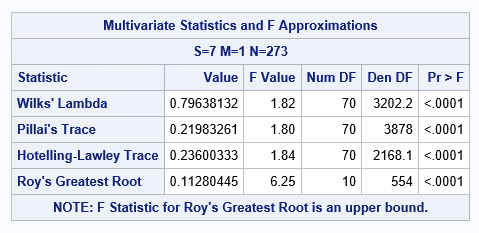

Next, the raw canonical coefficients are shown below.

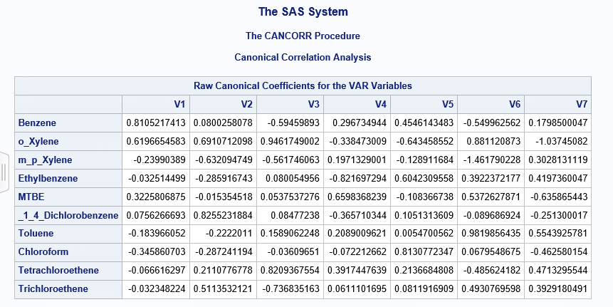

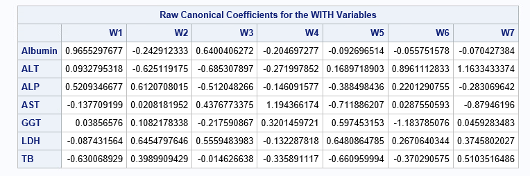

The raw canonical coefficients are interpreted in a manner analogous to interpreting regression coefficients. For the variable **o-Xylene**, a one unit increase in **o-Xylene** leads to a 0.6197 increase in the first canonical variate of set 1 when all of the other variables are held constant.

The raw coefficients are followed by the standardized canonical coefficients shown below. After standardizing, the coefficients are easier to compare because their values don’t depend on the their units. However, the raw coefficients are more interpretable.

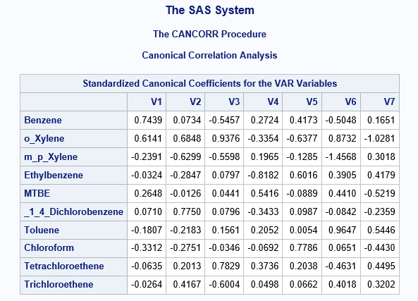

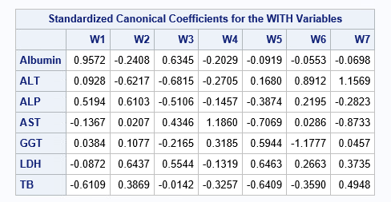

Below are correlations between observed variables and canonical variables which are known as the canonical loadings, which SAS labels as the canonical structure.

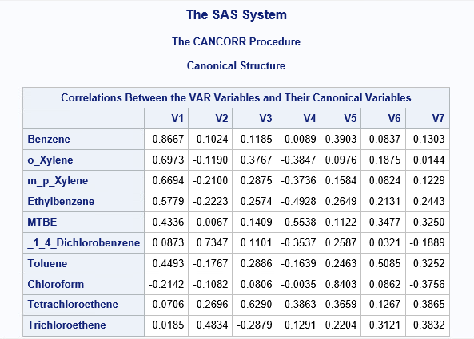

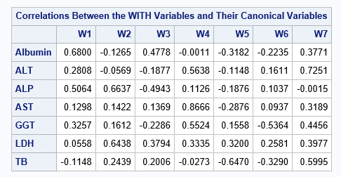

Through the graphes above, we can narrow down the relationship between the VOC exposure and liver function to fewer numbers of VOCs and liver function tests in the full group. in addition, it can imply that exposure to a cluster of certain VOCs mignt be associated with certain biochemical liver tests as a group.

**Canonical structures of the first pair of canonical variate and F-test (subgroup)**

```bash
proc cancorr data=project.moredrink;
var Benzene o_Xylene m_p_Xylene Ethylbenzene MTBE _1_4_Dichlorobenzene Toluene Chloroform Tetrachloroethene Trichloroethene;
with Albumin ALT ALP AST GGT LDH TB;
run;
```

The output below gives the canonical correlations and the multivariate tests of the dimensions, and also includes the multivariate criteria and the F approximations.

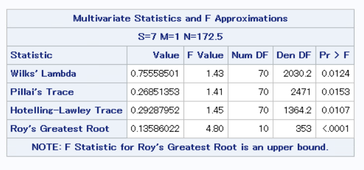

Next, the raw canonical coefficients are shown below.

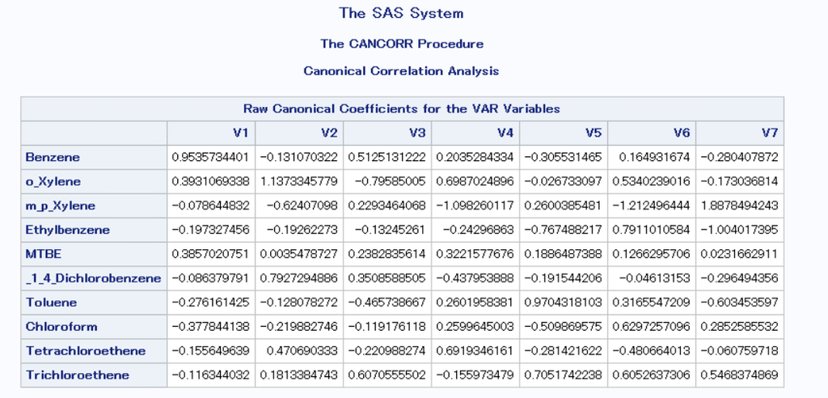

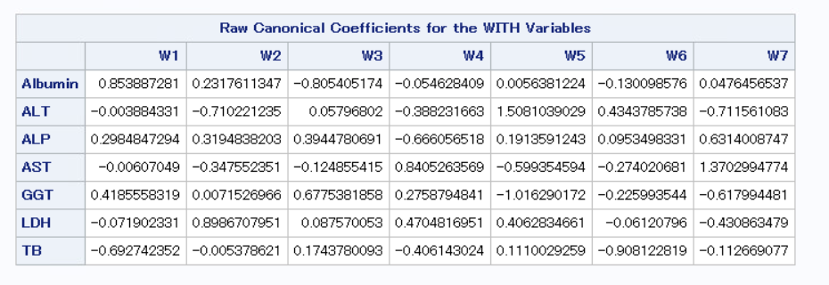

The raw canonical coefficients are interpreted in a manner analogous to interpreting regression coefficients. For the variable **o-Xylene**, a one unit increase in **o-Xylene** leads to a 0.3931 increase in the first canonical variate of set 1 when all of the other variables are held constant.

The raw coefficients are followed by the standardized canonical coefficients shown below.

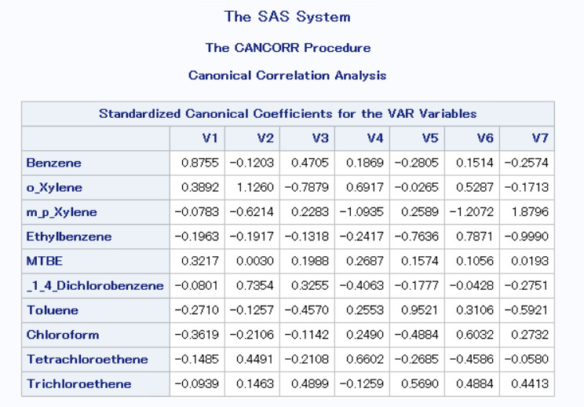

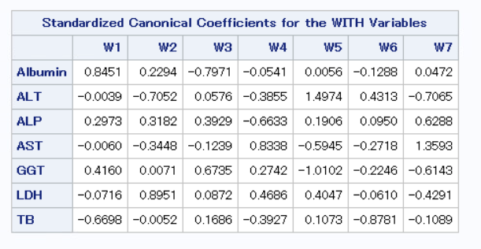

Below are correlations between observed variables and canonical variables which are known as the canonical loadings, which SAS labels as the canonical structure.

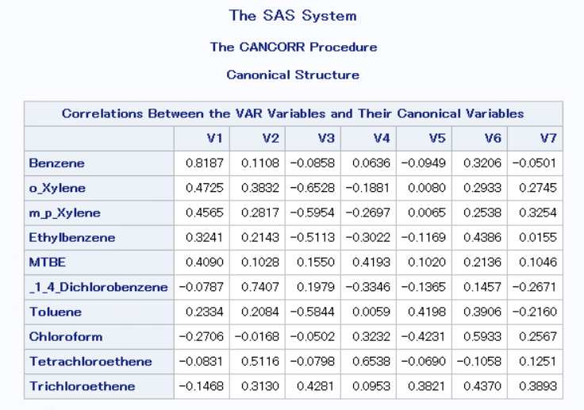

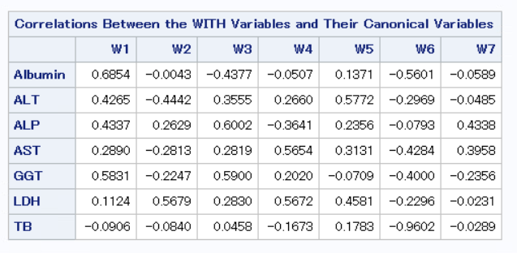

We can compare these graphes with the graphes of full group and see whether the change of group has influence on the correlation between the VOC exposure and liver function tests.

# Discussion

The advantages of CCA in this case:

- The liver damage caused by isolated VOCs maybe be even worse when facing a cluster of VOCs.
- The liver injuries would be better capture by the combination of liver function tests.
- Compared to the full model, subgroup implies that liver injuries may be caused by a narrower cluster of VOCs.

Take-home notes

- Canonical correlation terminology makes an important distinction between the words variables and variates. The term variables is reserved for referring to the original variables being analyzed. The term variates is used to refer to variables that are constructed as weighted averages of the original variables.
- CCA output can be fairly complex. Quantities of particular interest include the correlations between the original variables in each set and their respective canonical variates (structural correlations or loadings). The canonical correlations provide the concordance between the transformed variables, while the loadings reveal the extent to which each canonical variate is associated with particular variables in each set.
- In general, the number of canonical dimensions is equal to the number of variables in the smaller set; however, the number of significant dimensions may be even smaller. Canonical dimensions, also known as canonical variates, are latent variables that are analogous to factors in factor analysis.

# Alternative Methods

- Multivariate multiple regression
- Separate OLS Regressions

# Citation

*Burch, J. B., Everson, T. M., Seth, R. K., Wirth, M. D., & Chatterjee, S. (2015). Trihalomethane exposure and biomonitoring for the liver injury indicator, alanine aminotransferase, in the United States population (NHANES 1999-2006). Science of The Total Environment, 521-522, 226-234. doi:10.1016/j.scitotenv.2015.03.050*

*Liu, J., Drane, W., Liu, X., & Wu, T. (2009). Examination of the relationships between environmental exposures to volatile organic compounds and biochemical liver tests: Application of canonical correlation analysis. Environmental Research, 109(2), 193-199. doi:10.1016/j.envres.2008.11.002*

*Jang, E. S., Jeong, S., Hwang, S. H., Kim, H. Y., Ahn, S. Y., Lee, J.,… Lee, D. H. (2012). Effects of coffee, smoking, and alcohol on liver function tests: A comprehensive cross-sectional study. BMC Gastroenterology, 12(1). doi:10.1186/1471-230x-12-145*

*[Caconical Correlation by Wikipedia](https://en.wikipedia.org/wiki/Canonical_correlation)*

*[The Algorithm of CCA(Chinese version)](https://www.cnblogs.com/pinard/p/6288716.html)*

*[NCSS Statistical Software Chapter 400 Canonical Correlation](https://ncss-wpengine.netdna-ssl.com/wp-content/themes/ncss/pdf/Procedures/NCSS/Canonical_Correlation.pdf)*

*[Canonical Correlation Analysis by University of Minnesota](http://users.stat.umn.edu/~helwig/notes/cancor-Notes.pdf)*